# Informe Eventos Cardiacos

# Introduccion

Para poder trabajar de una manera optima con el dataset que se nos fue propocionado, procedimos a buscar informacion y recopilar investigaciones de medicos con experiencia cardiologia. Con una base lista comenzamos a analizar los datos y buscar posibles combinaciones que aporten informacion nueva a lo aportado

## Queries

Para poder definir nuestros Queries, procedimos a averiguar mas acerca de los sintomas que nos podian llegar a informar o predecir un posible evento cardiaco. A partir de esta ardua investigacion, procedimos a buscar relacionar esta informacion con los metadatas de nuestro dataset que se nos fue proporcionado. Juntando esto pudimos llegar a nuestras primeras queries

1. Metadatas que tienen mas peso en los eventos
2. Diabeticos con hipertension que son obesos y tienen eventos
3. Antecedentes familiares, con la edad y los eventos
4. Sme angioso con ubicacion de dolores y tuvieron evento
5. Porcentaje de sintomas de largo plazo que llevaron a evento
6. Densidad de eventos por edad en sintomas a largo plazo

# Analisis de Datos

## Genero

Este dato nos parecio muy importante ya que segun el *National institutes of Health*, en especial una investigacion del medico Neth Heart J, indica que estos eventos se darian mas en hombres que en mujeres

### Genero total

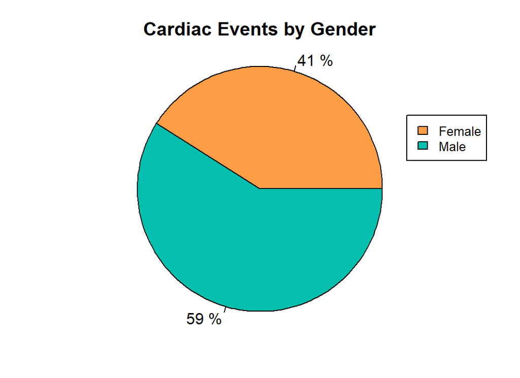

### Tuvieron un evento

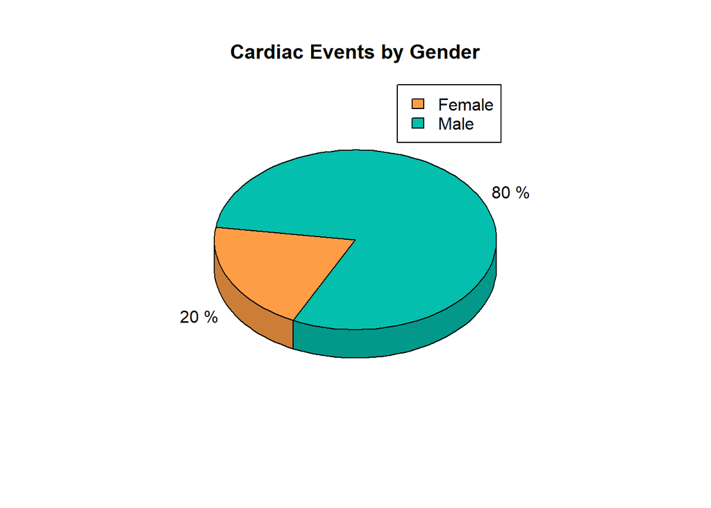

## Edad de quienes tuvieron algun evento cardiaco

### Grafico

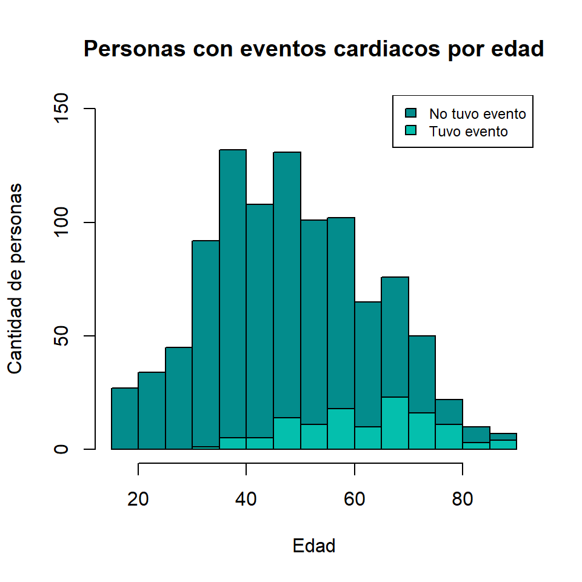

### Tabla

En esta tabla podemos notar claramente que la mayoria de los pacientes que sufren un evento pertenecen a la franja de edad de 32 a 80

| Etapa | Porcentaje |
| --- | --- |
| Adulto Joven | 0 |
| Adulto | 51 |
| Adulto Maduro | 49 |

## Sintomas Asociados

### Personas con evento

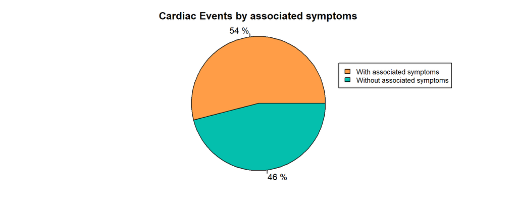

# Interpretacion

Para esta parte nos encargamos de buscar relaciones interesantes entre los datos que analizamos anteriormente

### Grafico

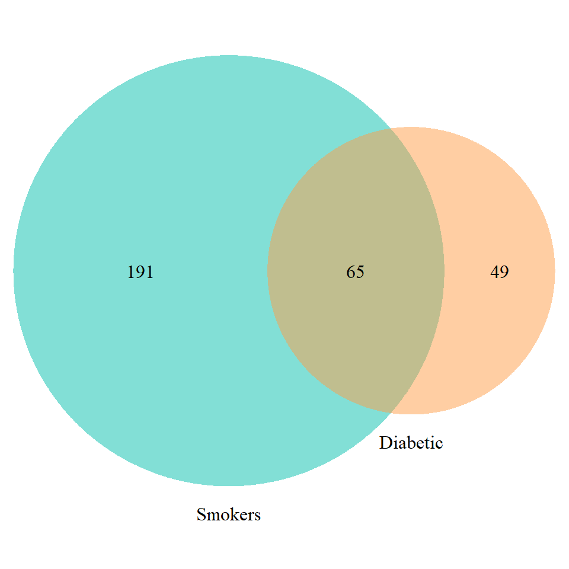

## Pacientes con obesidad y diabetes que tuvieron eventos

### Graficos

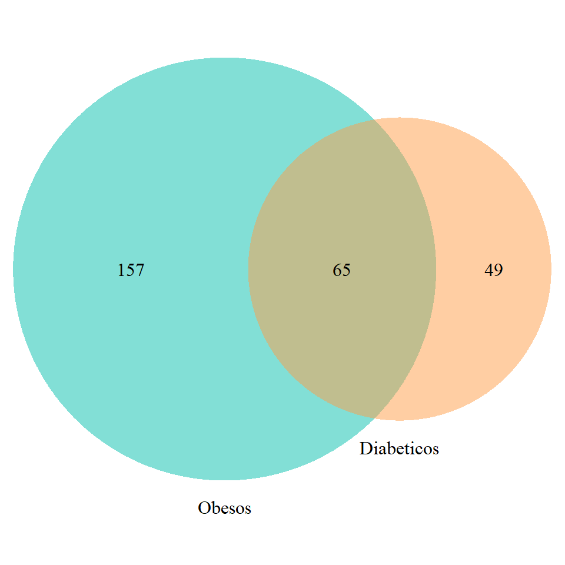

### Con eventos

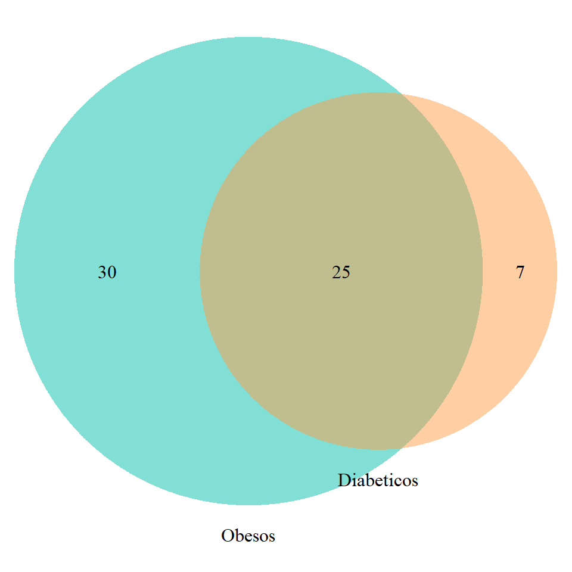

## Relacion entre obesos, diabeticos y antecedentes familiares

### Grafico

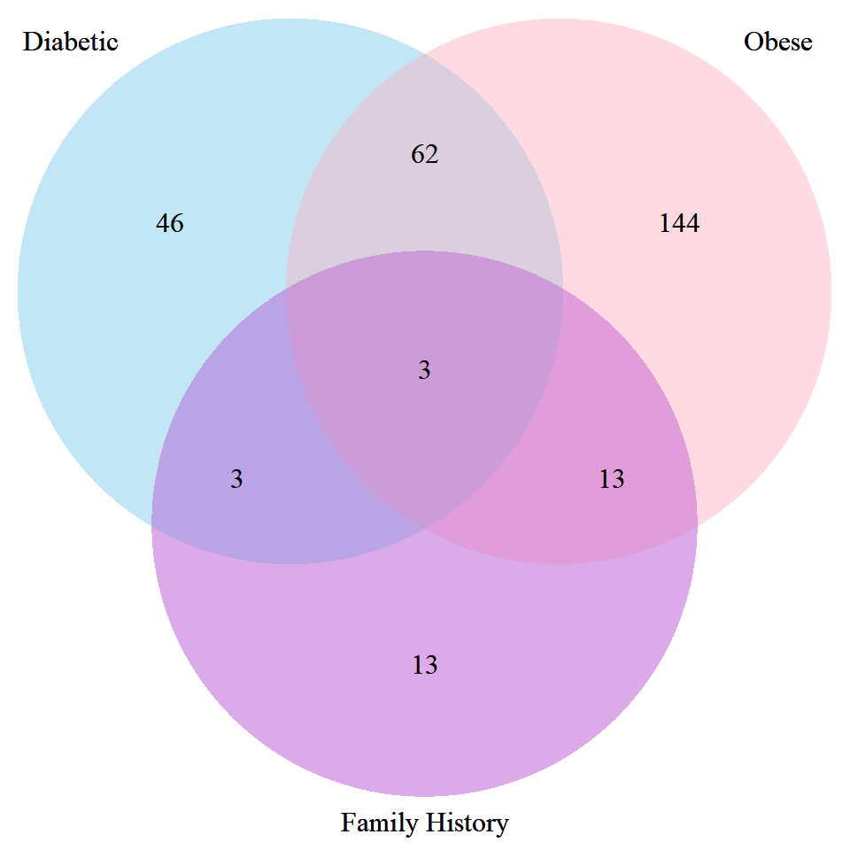

## Cantidad de eventos por duracion

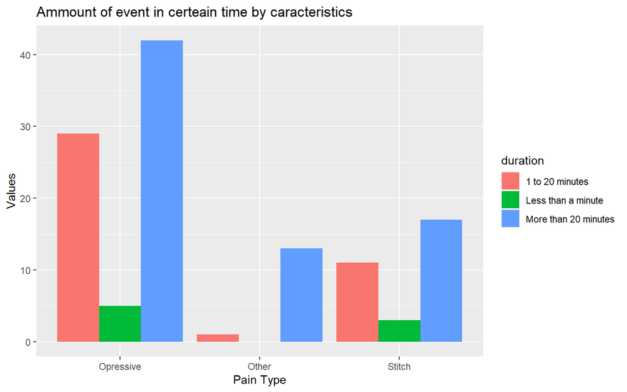

### Eventos por duracion

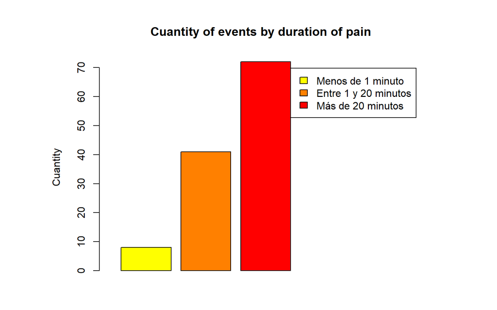

### Dolor opresivo

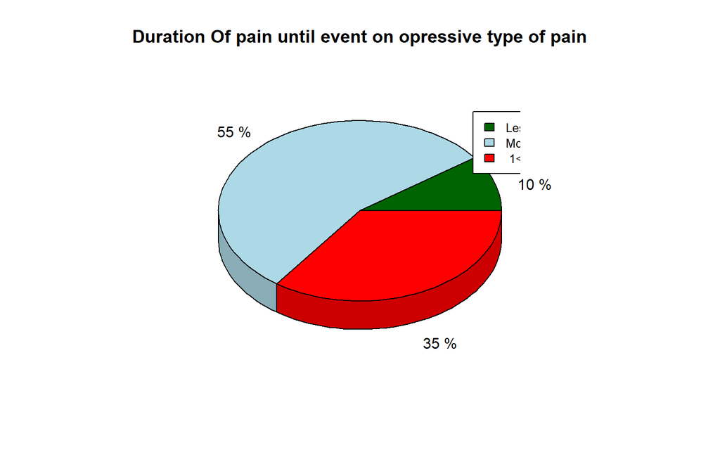